# Christian Gruenewald

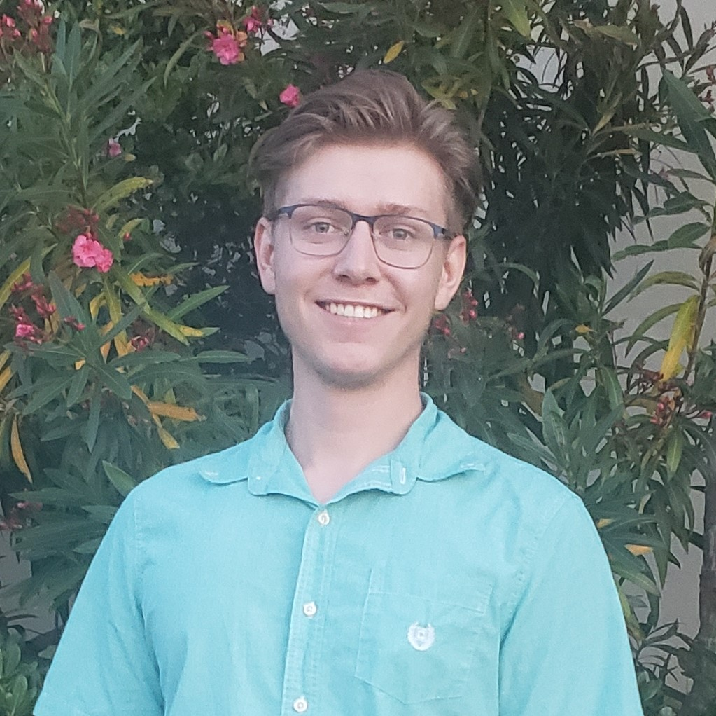

## About Me

Welcome to Christian Gruenewald’s Data Analytics Journey!

Are you ready to unlock the power of data? I’m Christian, a passionate data enthusiast armed with the Google Data Analytics Professional Certificate and a drive to make sense of the numbers. Whether it’s analyzing financial data, creating insightful dashboards, or cleaning messy datasets, I thrive on turning raw information into actionable insights.

As someone embarking on the journey to become a data analyst, I understand the importance of continuous learning and practical experience. Through hands-on projects and real-world applications, I’m honing my skills and expanding my knowledge in the field of data analytics.

On this website, I invite you to join me on this exciting adventure. Explore my portfolio, dive into my projects, and follow along as I document my progress and insights gained along the way. Whether you’re a fellow data enthusiast, a potential employer, or simply curious about the world of data analytics, I hope you’ll find inspiration and valuable insights here.

Let’s harness the power of data together and transform information into impact!